# TOBS: Topological Optimization of Binary Structures

## Description

This tutorial demonstrates TOBS on a 2D cantilever beam with 80×50 elements (4,000 design variables). The algorithm efficiently handles the combinatorial challenge of binary optimization through sequential linearization and branch- and-cut solving.

## Setup

```julia
using NonconvexTOBS, TopOpt
```

## Problem Definition

We use a large 2D cantilever beam to demonstrate TOBS scalability:

```julia
E = 1.0 # Young's modulus
v = 0.3 # Poisson's ratio
f = 1.0 # downward force
rmin = 6.0 # filter radius
xmin = 0.001 # minimum density
V = 0.5 # maximum volume fraction
p = 3.0 # topological optimization penalty

problem_size = (80, 50)  # 4,000 elements
x0 = fill(1.0, prod(problem_size))  # start from fully solid design
problem = PointLoadCantilever(Val{:Linear}, problem_size, (1.0, 1.0), E, v, f)
```

The mesh (80×50) tests TOBS ability to handle high-dimensional binary optimization problems.

## FEA Solver and Filter

```julia
solver = FEASolver(DirectSolver, problem; xmin=xmin)
cheqfilter = DensityFilterFun(solver; rmin=rmin)  # mesh-independent filtering
comp = ComplianceFun(solver)
```

The density filter ensures smooth designs and prevents checkerboarding, critical for binary optimization where small features can cause numerical instability.

## Objective and Constraint

```julia
obj(x) = comp(cheqfilter(PseudoDensities(x)))  # compliance objective
constr(x) = sum(cheqfilter(PseudoDensities(x))) / length(x) - V  # volume constraint
```

The objective minimizes compliance (strain energy) while the constraint limits material usage to 50% of the domain volume.

## Optimization Setup

```julia
m = Model(obj)
addvar!(m, zeros(length(x0)), ones(length(x0)))  # bounds: 0 ≤ xᵢ ≤ 1
Nonconvex.add_ineq_constraint!(m, constr)
# TOBS starts from the provided x0 and flips at most
# `movelimit * numVars` variables per iteration, so reaching the 50%
# volume target from 100% solid needs enough iterations to remove half
# the material.
options = TOBSOptions(; maxiter=100, movelimit=0.05)
setpenalty!(solver, p)
```

TOBS uses binary variables (0 or 1) with bound constraints. The penalty exponent p=3.0 penalizes intermediate densities in the FEA solution.

## Run TOBS Optimization

```julia
@time r = Nonconvex.optimize(m, TOBSAlg(), x0; options=options)
```

[output not shown]

[output cut: 71 more lines]

```
[ Info: iter = 86, obj = 50.89, constr_vio_norm = 0.0, er = 0.028
[ Info: iter = 87, obj = 49.48, constr_vio_norm = 0.0, er = 0.029
[ Info: iter = 88, obj = 51.095, constr_vio_norm = 0.0, er = 0.029
[ Info: iter = 89, obj = 48.942, constr_vio_norm = 0.0, er = 0.025
[ Info: iter = 90, obj = 49.334, constr_vio_norm = 0.0, er = 0.019
[ Info: iter = 91, obj = 49.582, constr_vio_norm = 0.0, er = 0.019
[ Info: iter = 92, obj = 50.861, constr_vio_norm = 0.0, er = 0.02
[ Info: iter = 93, obj = 49.25, constr_vio_norm = 0.0, er = 0.02
[ Info: iter = 94, obj = 50.716, constr_vio_norm = 0.0, er = 0.019
[ Info: iter = 95, obj = 48.787, constr_vio_norm = 0.0, er = 0.02
[ Info: iter = 96, obj = 48.727, constr_vio_norm = 0.0, er = 0.018
[ Info: iter = 97, obj = 49.541, constr_vio_norm = 0.0, er = 0.019
[ Info: iter = 98, obj = 50.902, constr_vio_norm = 0.0, er = 0.02
[ Info: iter = 99, obj = 49.291, constr_vio_norm = 0.0, er = 0.021
136.816604 seconds (94.14 M allocations: 6.266 GiB, 2.46% gc time, 15.66% compilation time: 14% of which was recompilation)
```

```
NonconvexTOBS.TOBSResult{Vector{Float64}, Float64, Float64}([1.0, 1.0, 1.0, 1.0, 1.0, 1.0, 1.0, 1.0, 1.0, 1.0  …  0.0, 0.0, 0.0, 0.0, 0.0, 0.0, 0.0, 0.0, 0.0, 0.0], 52.5688729268142, 0.020746542606050015)
```

The TOBS algorithm iterates:

1. Linearize objective and constraints around current design
2. Solve binary subproblem with Cbc.jl
3. Determine which variables to flip (0→1 or 1→0)
4. Update design and repeat

## Results

```julia
@show obj(r.minimizer)
@show constr(r.minimizer)
```

```
obj(r.minimizer) = 52.5688729268142
constr(r.minimizer) = -4.461606362138326e-9
```

```
-4.461606362138326e-9
```

The final design should be nearly binary (values close to 0 or 1) with satisfied volume constraint. TOBS typically produces crisp black/white designs without intermediate densities.

## Visualization

[output not shown]

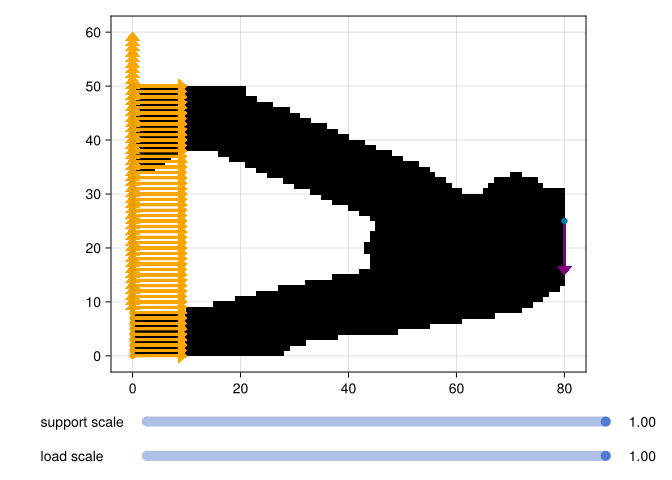

Figure 1: TOBS optimization result showing binary (0/1) material distribution

```julia
using CairoMakie
topology = r.minimizer
fig = visualize(problem; topology=topology)
```

The visualization shows the final binary structure — TOBS naturally produces clean 0/1 designs without the gray regions common in SIMP results.